# 12==== Examples

Since the model with the generic time coefficient is a restricted version of the model with the specific time coefficient (beta car= beta walk = beta cycle = beta HSR), it is possible to compare both models with a likelihood ratio test.

```r
lrtest(model2,model3)
```

```
Likelihood ratio test

Model 1: choice ~ time | sidewalk_density
Model 2: choice ~ 0 | sidewalk_density | time
  #Df  LogLik Df  Chisq Pr(>Chisq)
1   7 -760.42
2  10 -684.75  3 151.34  < 2.2e-16 ***
---
Signif. codes:  0 ‘***’ 0.001 ‘**’ 0.01 ‘*’ 0.05 ‘.’ 0.1 ‘ ’ 1
```

We can also include transit specific attributes (wait and transfer). Since there is only one alternative with these attributes, there will be only one coefficient, which can be included as generic:

```r
f8 <- mFormula(choice ~ wait + transfer | sidewalk_density | time  )
model8 <- mlogit(f8, mc_commute_long, reflevel = "HSR")
summary(model8)
```

```
Call:
mlogit(formula = choice ~ wait + transfer | sidewalk_density |
    time, data = mc_commute_long, reflevel = "HSR", method = "nr")

Frequencies of alternatives:choice
     HSR      Car    Cycle     Walk
0.244364 0.204364 0.034182 0.517091

nr method
6 iterations, 0h:0m:0s
g'(-H)^-1g = 1.93E-05
successive function values within tolerance limits

Coefficients :
                         Estimate Std. Error z-value  Pr(>|z|)
(Intercept):Car        -1.2734305  0.3161623 -4.0278 5.631e-05 ***
(Intercept):Cycle      -3.7343806  0.8270472 -4.5153 6.322e-06 ***
(Intercept):Walk        3.2694451  0.4073725  8.0257 1.110e-15 ***
wait                   -0.0006563  0.0155763 -0.0421 0.9663914
transfer               -0.1741390  0.1312282 -1.3270 0.1845108
sidewalk_density:Car   -0.0015020  0.0087080 -0.1725 0.8630542
sidewalk_density:Cycle  0.0530551  0.0187767  2.8256 0.0047196 **
sidewalk_density:Walk   0.0255201  0.0091865  2.7780 0.0054697 **
time:HSR               -0.0189304  0.0063879 -2.9635 0.0030417 **
time:Car                0.0447668  0.0131840  3.3955 0.0006849 ***
time:Cycle              0.2345670  0.0590356  3.9733 7.088e-05 ***
time:Walk              -0.1277932  0.0138084 -9.2547 < 2.2e-16 ***
---
Signif. codes:  0 ‘***’ 0.001 ‘**’ 0.01 ‘*’ 0.05 ‘.’ 0.1 ‘ ’ 1

Log-Likelihood: -683.85
McFadden R^2:  0.55802
Likelihood ratio test : chisq = 1726.8 (p.value = < 2.22e-16)
```

Let’s now add socio-economic characteristics:

```r
f9 <- mFormula(choice ~ wait + transfer | sidewalk_density + gender + child | time)
model9 <- mlogit(f9, mc_commute_long)
summary(model9)
```

```
Call:
mlogit(formula = choice ~ wait + transfer | sidewalk_density +
    gender + child | time, data = mc_commute_long, method = "nr")

Frequencies of alternatives:choice
     Car    Cycle      HSR     Walk
0.204364 0.034182 0.244364 0.517091

nr method
6 iterations, 0h:0m:0s
g'(-H)^-1g = 0.000213
successive function values within tolerance limits

Coefficients :
                          Estimate  Std. Error z-value  Pr(>|z|)
(Intercept):Cycle      -2.85354249  0.93452298 -3.0535  0.002262 **
(Intercept):HSR         1.39369151  0.33358744  4.1779 2.942e-05 ***
(Intercept):Walk        4.94878142  0.47438534 10.4320 < 2.2e-16 ***
wait                   -0.00066729  0.01559426 -0.0428  0.965868
transfer               -0.19759337  0.13677167 -1.4447  0.148544
sidewalk_density:Cycle  0.05082733  0.02076673  2.4475  0.014384 *
sidewalk_density:HSR    0.00111338  0.00875511  0.1272  0.898806
sidewalk_density:Walk   0.02640721  0.01207022  2.1878  0.028684 *
genderMale:Cycle        0.21717590  0.46567053  0.4664  0.640949
genderMale:HSR         -0.16327528  0.19310176 -0.8455  0.397809
genderMale:Walk        -0.69578784  0.27705503 -2.5114  0.012026 *
childYes:Cycle         -2.64384071  0.95504175 -2.7683  0.005635 **
childYes:HSR           -0.08574223  0.21384072 -0.4010  0.688447
childYes:Walk          -0.04438615  0.58503796 -0.0759  0.939523
time:Car                0.04226547  0.01338025  3.1588  0.001584 **
time:Cycle              0.31186738  0.07041461  4.4290 9.466e-06 ***
time:HSR               -0.01947651  0.00653702 -2.9794  0.002888 **
time:Walk              -0.13204288  0.01469130 -8.9878 < 2.2e-16 ***
---
Signif. codes:  0 ‘***’ 0.001 ‘**’ 0.01 ‘*’ 0.05 ‘.’ 0.1 ‘ ’ 1

Log-Likelihood: -673.57
McFadden R^2:  0.56466
Likelihood ratio test : chisq = 1747.3 (p.value = < 2.22e-16)
```

Let’s now look a bit closer to the street density and sidewalk density variables:

```r
f3 <- mFormula(choice ~ time | sidewalk_density | 0)
model3 <- mlogit(f3, mc_commute_long)
summary(model3)
```

```
Call:
mlogit(formula = choice ~ time | sidewalk_density | 0, data = mc_commute_long,
    method = "nr")

Frequencies of alternatives:choice
     Car    Cycle      HSR     Walk
0.204364 0.034182 0.244364 0.517091

nr method
5 iterations, 0h:0m:0s
g'(-H)^-1g = 0.000287
successive function values within tolerance limits

Coefficients :
                         Estimate Std. Error z-value  Pr(>|z|)
(Intercept):Cycle      -0.3058620  0.4541379 -0.6735  0.500629
(Intercept):HSR         0.6761001  0.2150745  3.1436  0.001669 **
(Intercept):Walk        2.3453233  0.3124706  7.5057 6.106e-14 ***
time                   -0.0562191  0.0056910 -9.8785 < 2.2e-16 ***
sidewalk_density:Cycle  0.0273085  0.0169331  1.6127  0.106803
sidewalk_density:HSR    0.0016950  0.0085746  0.1977  0.843299
sidewalk_density:Walk   0.0350392  0.0111749  3.1355  0.001715 **
---
Signif. codes:  0 ‘***’ 0.001 ‘**’ 0.01 ‘*’ 0.05 ‘.’ 0.1 ‘ ’ 1

Log-Likelihood: -760.42
McFadden R^2:  0.50854
Likelihood ratio test : chisq = 1573.7 (p.value = < 2.22e-16)
```

```r
f5 <- mFormula(choice ~ time |street_density)
model5 <- mlogit(f5, mc_commute_long)
summary(model5)
```

```
Call:
mlogit(formula = choice ~ time | street_density, data = mc_commute_long,
    method = "nr")

Frequencies of alternatives:choice
     Car    Cycle      HSR     Walk
0.204364 0.034182 0.244364 0.517091

nr method
5 iterations, 0h:0m:0s
g'(-H)^-1g = 0.000102
successive function values within tolerance limits

Coefficients :
                       Estimate Std. Error z-value  Pr(>|z|)
(Intercept):Cycle     0.4212490  0.6284794  0.6703   0.50269
(Intercept):HSR       0.6860123  0.2798654  2.4512   0.01424 *
(Intercept):Walk      2.9145042  0.4349985  6.7000 2.084e-11 ***
time                 -0.0564558  0.0057437 -9.8292 < 2.2e-16 ***
street_density:Cycle -0.0040916  0.0446140 -0.0917   0.92693
street_density:HSR    0.0016784  0.0193644  0.0867   0.93093
street_density:Walk   0.0217106  0.0289936  0.7488   0.45397
---
Signif. codes:  0 ‘***’ 0.001 ‘**’ 0.01 ‘*’ 0.05 ‘.’ 0.1 ‘ ’ 1

Log-Likelihood: -768.17
McFadden R^2:  0.50352
Likelihood ratio test : chisq = 1558.2 (p.value = < 2.22e-16)
```

What happens if we include both

```r
f7 <- mFormula(choice ~ time | sidewalk_density + street_density)
model7 <- mlogit(f7, mc_commute_long)
summary(model7)
```

```
Call:
mlogit(formula = choice ~ time | sidewalk_density + street_density,
    data = mc_commute_long, method = "nr")

Frequencies of alternatives:choice
     Car    Cycle      HSR     Walk
0.204364 0.034182 0.244364 0.517091

nr method
5 iterations, 0h:0m:0s
g'(-H)^-1g = 0.000709
successive function values within tolerance limits

Coefficients :
                          Estimate  Std. Error z-value  Pr(>|z|)
(Intercept):Cycle       1.02997503  0.66008086  1.5604  0.118671
(Intercept):HSR         0.66742770  0.27975431  2.3858  0.017044 *
(Intercept):Walk        3.47748252  0.45601605  7.6258 2.420e-14 ***
time                   -0.05545590  0.00572523 -9.6862 < 2.2e-16 ***
sidewalk_density:Cycle  0.09675924  0.03240942  2.9855  0.002831 **
sidewalk_density:HSR    0.00119639  0.01233917  0.0970  0.922759
sidewalk_density:Walk   0.08643895  0.01810649  4.7739 1.807e-06 ***
street_density:Cycle   -0.22675882  0.08609527 -2.6338  0.008443 **
street_density:HSR      0.00094748  0.02784067  0.0340  0.972851
street_density:Walk    -0.17698883  0.04799011 -3.6880  0.000226 ***
---
Signif. codes:  0 ‘***’ 0.001 ‘**’ 0.01 ‘*’ 0.05 ‘.’ 0.1 ‘ ’ 1

Log-Likelihood: -749.83
McFadden R^2:  0.51538
Likelihood ratio test : chisq = 1594.8 (p.value = < 2.22e-16)
```

The signs for street density become negative and significant for cycling and walking.

Are the results logical? Intuitive? Denser streets = less walking and cycling compared to car?

```r
cor(mc_commute$sidewalk_density,mc_commute$street_density)
```

```
[1] 0.7932912
```

We can try creating a new variable to avoid issues of correlation. Sidewalk ratio= proportion of sidewalk to streets

```r
mc_commute_long$sidewalk_ratio = mc_commute_long$sidewalk_density/mc_commute_long$street_density
f6 <- mFormula(choice ~ time |sidewalk_ratio)
model6 <- mlogit(f6, mc_commute_long)
summary(model6)
```

```
Call:
mlogit(formula = choice ~ time | sidewalk_ratio, data = mc_commute_long,
    method = "nr")

Frequencies of alternatives:choice
     Car    Cycle      HSR     Walk
0.203933 0.034232 0.243991 0.517844

nr method
5 iterations, 0h:0m:0s
g'(-H)^-1g = 0.000985
successive function values within tolerance limits

Coefficients :
                       Estimate Std. Error z-value  Pr(>|z|)
(Intercept):Cycle    -1.7302487  0.6987920 -2.4761  0.013284 *
(Intercept):HSR       0.6032220  0.2444024  2.4682  0.013581 *
(Intercept):Walk      0.9968030  0.3985224  2.5012  0.012376 *
time                 -0.0556422  0.0056695 -9.8143 < 2.2e-16 ***
sidewalk_ratio:Cycle  1.2018512  0.3796150  3.1660  0.001546 **
sidewalk_ratio:HSR    0.0674130  0.1396120  0.4829  0.629195
sidewalk_ratio:Walk   1.2785360  0.2202830  5.8041 6.473e-09 ***
---
Signif. codes:  0 ‘***’ 0.001 ‘**’ 0.01 ‘*’ 0.05 ‘.’ 0.1 ‘ ’ 1

Log-Likelihood: -744.53
McFadden R^2:  0.51787
Likelihood ratio test : chisq = 1599.4 (p.value = < 2.22e-16)
```

More sidewalk/street = more cycling and walking. Why? Type of environment? Suburban vs not?

Coming back to a simpler model:

```r
f2 <- mFormula(choice ~ time | sidewalk_density)
model2 <- mlogit(f2, mc_commute_long)
summary(model2)
```

```
Call:
mlogit(formula = choice ~ time | sidewalk_density, data = mc_commute_long,
    method = "nr")

Frequencies of alternatives:choice
     Car    Cycle      HSR     Walk
0.204364 0.034182 0.244364 0.517091

nr method
5 iterations, 0h:0m:0s
g'(-H)^-1g = 0.000287
successive function values within tolerance limits

Coefficients :
                         Estimate Std. Error z-value  Pr(>|z|)
(Intercept):Cycle      -0.3058620  0.4541379 -0.6735  0.500629
(Intercept):HSR         0.6761001  0.2150745  3.1436  0.001669 **
(Intercept):Walk        2.3453233  0.3124706  7.5057 6.106e-14 ***
time                   -0.0562191  0.0056910 -9.8785 < 2.2e-16 ***
sidewalk_density:Cycle  0.0273085  0.0169331  1.6127  0.106803
sidewalk_density:HSR    0.0016950  0.0085746  0.1977  0.843299
sidewalk_density:Walk   0.0350392  0.0111749  3.1355  0.001715 **
---
Signif. codes:  0 ‘***’ 0.001 ‘**’ 0.01 ‘*’ 0.05 ‘.’ 0.1 ‘ ’ 1

Log-Likelihood: -760.42
McFadden R^2:  0.50854
Likelihood ratio test : chisq = 1573.7 (p.value = < 2.22e-16)
```

Adding the gender variable:

```r
f10 <- mFormula(choice ~ time | sidewalk_density + gender)
model10 <- mlogit(f10, mc_commute_long)
summary(model10)
```

```
Call:
mlogit(formula = choice ~ time | sidewalk_density + gender, data = mc_commute_long,
    method = "nr")

Frequencies of alternatives:choice
     Car    Cycle      HSR     Walk
0.204364 0.034182 0.244364 0.517091

nr method
5 iterations, 0h:0m:0s
g'(-H)^-1g = 0.000431
successive function values within tolerance limits

Coefficients :
                         Estimate Std. Error z-value  Pr(>|z|)
(Intercept):Cycle      -0.3520735  0.4925778 -0.7148  0.474759
(Intercept):HSR         0.7340609  0.2310652  3.1769  0.001489 **
(Intercept):Walk        2.5627878  0.3338911  7.6755 1.643e-14 ***
time                   -0.0569505  0.0057117 -9.9709 < 2.2e-16 ***
sidewalk_density:Cycle  0.0274716  0.0169605  1.6197  0.105288
sidewalk_density:HSR    0.0017190  0.0085835  0.2003  0.841273
sidewalk_density:Walk   0.0356208  0.0111941  3.1821  0.001462 **
genderMale:Cycle        0.0481604  0.3870787  0.1244  0.900983
genderMale:HSR         -0.1145710  0.1898832 -0.6034  0.546258
genderMale:Walk        -0.5060140  0.2575987 -1.9643  0.049490 *
---
Signif. codes:  0 ‘***’ 0.001 ‘**’ 0.01 ‘*’ 0.05 ‘.’ 0.1 ‘ ’ 1

Log-Likelihood: -757.48
McFadden R^2:  0.51043
Likelihood ratio test : chisq = 1579.5 (p.value = < 2.22e-16)
```

Men are less likely to walk than to take the car compared to women. In line with theory, but performance of the model is not statistically different (see below). We can nonetheless keep the gender variable in as the results are consistent with theory and the model remains stable.

```r
lrtest(model2,model10)
```

```
Likelihood ratio test

Model 1: choice ~ time | sidewalk_density
Model 2: choice ~ time | sidewalk_density + gender
  #Df  LogLik Df Chisq Pr(>Chisq)
1   7 -760.42
2  10 -757.48  3  5.87     0.1181
```

Comparing with dsecriptive statistics:

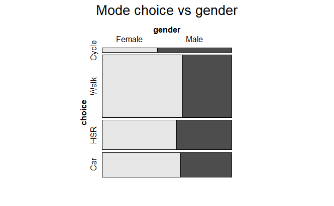

```r
mosaic(gender ~ choice, mc_commute, main="Mode choice vs gender")
```

## Example: A nested logit model of mode choice

Previous logit model

```r
f3 <- mFormula(choice ~ 0 | sidewalk_density + gender | time)
model3 <- mlogit(f3, mc_commute_long)
summary(model3)
```

```
Call:
mlogit(formula = choice ~ 0 | sidewalk_density + gender | time,
    data = mc_commute_long, method = "nr")

Frequencies of alternatives:choice
     Car    Cycle      HSR     Walk
0.204364 0.034182 0.244364 0.517091

nr method
6 iterations, 0h:0m:0s
g'(-H)^-1g = 4.07E-05
successive function values within tolerance limits

Coefficients :
                         Estimate Std. Error z-value  Pr(>|z|)
(Intercept):Cycle      -2.6214686  0.8902436 -2.9447 0.0032331 **
(Intercept):HSR         1.3487272  0.2840392  4.7484 2.050e-06 ***
(Intercept):Walk        4.8674848  0.4650087 10.4675 < 2.2e-16 ***
sidewalk_density:Cycle  0.0536927  0.0202137  2.6562 0.0079015 **
sidewalk_density:HSR    0.0013448  0.0086983  0.1546 0.8771359
sidewalk_density:Walk   0.0276085  0.0119961  2.3015 0.0213661 *
genderMale:Cycle        0.2437548  0.4448090  0.5480 0.5836927
genderMale:HSR         -0.1609050  0.1924040 -0.8363 0.4029935
genderMale:Walk        -0.6887835  0.2762020 -2.4938 0.0126395 *
time:Car                0.0446831  0.0131608  3.3952 0.0006859 ***
time:Cycle              0.2359647  0.0590046  3.9991 6.359e-05 ***
time:HSR               -0.0232483  0.0057690 -4.0299 5.581e-05 ***
time:Walk              -0.1305185  0.0139500 -9.3561 < 2.2e-16 ***
---
Signif. codes:  0 ‘***’ 0.001 ‘**’ 0.01 ‘*’ 0.05 ‘.’ 0.1 ‘ ’ 1

Log-Likelihood: -680.11
McFadden R^2:  0.56044
Likelihood ratio test : chisq = 1734.3 (p.value = < 2.22e-16)
```

Nested logit Active vs Motorized

```r
nl2 <- mlogit(choice ~ 0 | sidewalk_density + gender | time, mc_commute_long,
             nests = list(active = c( 'Cycle', 'Walk'), motorized = c('HSR', 'Car')),
             un.nest.el = FALSE,
             steptol = 1e-12)
summary(nl2)
```

```
Call:
mlogit(formula = choice ~ 0 | sidewalk_density + gender | time,
    data = mc_commute_long, nests = list(active = c("Cycle",
        "Walk"), motorized = c("HSR", "Car")),
    un.nest.el = FALSE, steptol = 1e-12)

Frequencies of alternatives:choice
     Car    Cycle      HSR     Walk
0.204364 0.034182 0.244364 0.517091

bfgs method
33 iterations, 0h:0m:1s
g'(-H)^-1g = 9.84E-07
gradient close to zero

Coefficients :
                          Estimate  Std. Error z-value  Pr(>|z|)
(Intercept):Cycle      -6.7204e-01  1.0342e+00 -0.6498  0.515829
(Intercept):HSR        -8.5845e-02  4.7882e-01 -0.1793  0.857714
(Intercept):Walk        2.8677e+00  5.2100e-01  5.5042 3.708e-08 ***
sidewalk_density:Cycle  3.2105e-02  2.4015e-02  1.3369  0.181262
sidewalk_density:HSR   -4.3262e-05  5.9665e-04 -0.0725  0.942197
sidewalk_density:Walk   2.6106e-02  8.2103e-03  3.1796  0.001475 **
genderMale:Cycle       -2.3990e-01  4.6093e-01 -0.5205  0.602730
genderMale:HSR          1.4103e-02  7.9037e-02  0.1784  0.858384
genderMale:Walk        -4.4531e-01  2.1437e-01 -2.0774  0.037768 *
time:Car               -1.5245e-03  8.5895e-03 -0.1775  0.859124
time:Cycle              1.0926e-02  5.5207e-02  0.1979  0.843112
time:HSR                2.0673e-03  1.1516e-02  0.1795  0.857528
time:Walk              -9.3277e-02  1.1127e-02 -8.3829 < 2.2e-16 ***
iv:active               2.8822e-01  9.2792e-02  3.1061  0.001896 **
iv:motorized           -6.1123e-02  3.4121e-01 -0.1791  0.857833
---
Signif. codes:  0 ‘***’ 0.001 ‘**’ 0.01 ‘*’ 0.05 ‘.’ 0.1 ‘ ’ 1

Log-Likelihood: -662.32
McFadden R^2:  0.57194
Likelihood ratio test : chisq = 1769.9 (p.value = < 2.22e-16)
```

Negative inclusive value: not consistent with random utility maximization. (If lambda increases, utility decreases). Model is not valid

```r
1 - nl2$coefficients["iv:active"]
```

```
iv:active
0.7117827
```

```r
1 - nl2$coefficients["iv:motorized"]
```

```
iv:motorized
    1.061123
```

```r
lrtest(nl2,model3)
```

```
Likelihood ratio test

Model 1: choice ~ 0 | sidewalk_density + gender | time
Model 2: choice ~ 0 | sidewalk_density + gender | time
  #Df  LogLik Df  Chisq Pr(>Chisq)
1  15 -662.32
2  13 -680.11 -2 35.584  1.875e-08 ***
---
Signif. codes:  0 ‘***’ 0.001 ‘**’ 0.01 ‘*’ 0.05 ‘.’ 0.1 ‘ ’ 1
```

We gain information but..?

What happens if we coerce to identical lambdas?

```r
nl3 <- mlogit(choice ~ 0 | sidewalk_density + gender | time, mc_commute_long,
             nests = list(active = c( 'Cycle', 'Walk'), motorized = c('HSR', 'Car')),
             un.nest.el = TRUE,
             steptol = 1e-12)
summary(nl3)
```

```
Call:
mlogit(formula = choice ~ 0 | sidewalk_density + gender | time,
    data = mc_commute_long, nests = list(active = c("Cycle",
        "Walk"), motorized = c("HSR", "Car")),
    un.nest.el = TRUE, steptol = 1e-12)

Frequencies of alternatives:choice
     Car    Cycle      HSR     Walk
0.204364 0.034182 0.244364 0.517091

bfgs method
20 iterations, 0h:0m:0s
g'(-H)^-1g = 7.24E-08
gradient close to zero

Coefficients :
                          Estimate  Std. Error z-value  Pr(>|z|)
(Intercept):Cycle      -0.13133420  0.86487717 -0.1519 0.8793029
(Intercept):HSR         0.37378986  0.14487045  2.5802 0.0098753 **
(Intercept):Walk        3.23042606  0.39621770  8.1532 4.441e-16 ***
sidewalk_density:Cycle  0.03207761  0.02362806  1.3576 0.1745885
sidewalk_density:HSR    0.00024013  0.00237192  0.1012 0.9193609
sidewalk_density:Walk   0.02692754  0.00814437  3.3063 0.0009455 ***
genderMale:Cycle       -0.30730107  0.44841333 -0.6853 0.4931498
genderMale:HSR         -0.05775095  0.05540979 -1.0423 0.2972950
genderMale:Walk        -0.49188907  0.20991849 -2.3432 0.0191172 *
time:Car                0.00827075  0.00448336  1.8448 0.0650716 .
time:Cycle             -0.00320122  0.05215935 -0.0614 0.9510615
time:HSR               -0.00821274  0.00316598 -2.5941 0.0094849 **
time:Walk              -0.09230396  0.01096772 -8.4160 < 2.2e-16 ***
iv                      0.26649066  0.08492577  3.1379 0.0017015 **
---
Signif. codes:  0 ‘***’ 0.001 ‘**’ 0.01 ‘*’ 0.05 ‘.’ 0.1 ‘ ’ 1

Log-Likelihood: -662.75
McFadden R^2:  0.57166
Likelihood ratio test : chisq = 1769 (p.value = < 2.22e-16)
```

Does it make sense to use the same inclusive value?

```r
1 - 0.266
```

```
[1] 0.734
```

The value is between the two inclusive values above.

Comparison with the logit model:

```r
lrtest(nl3,model3)
```

```
Likelihood ratio test

Model 1: choice ~ 0 | sidewalk_density + gender | time
Model 2: choice ~ 0 | sidewalk_density + gender | time
  #Df  LogLik Df  Chisq Pr(>Chisq)
1  14 -662.75
2  13 -680.11 -1 34.724  3.799e-09 ***
---
Signif. codes:  0 ‘***’ 0.001 ‘**’ 0.01 ‘*’ 0.05 ‘.’ 0.1 ‘ ’ 1
```

Can we compare the nested logit with a likelihood test?

```r
lrtest(nl3,nl2)
```

```
Likelihood ratio test

Model 1: choice ~ 0 | sidewalk_density + gender | time
Model 2: choice ~ 0 | sidewalk_density + gender | time
  #Df  LogLik Df  Chisq Pr(>Chisq)
1  14 -662.75
2  15 -662.32  1 0.8601     0.3537
```

No statistically significant difference. (But in any case, there is no reason to use such nest structure given the different lambdas we obtain)

Let’s try other structures:

Nested active and public transport vs car

```r
nl4 <- mlogit(choice ~ 0 | sidewalk_density + gender | time, mc_commute_long,
             nests = list(active = c( 'Cycle', 'Walk','HSR'), motorized = c('Car')),
             un.nest.el = FALSE,
             steptol = 1e-12)
```

```
Error in solve.default(crossprod(attr(x, "gradi")[, !fixed])) :
  le système est numériquement singulier : conditionnement de la réciproque = 3.09351e-37
```

Not possible to solve the model with different lambdas.

What happens if we coerce to the same lambda?

```r
nl5 <- mlogit(choice ~ 0 | sidewalk_density + gender | time, mc_commute_long,
             nests = list(active = c( 'Cycle', 'Walk','HSR'), motorized = c('Car')),
             un.nest.el = TRUE,
             steptol = 1e-12)
summary(nl5)
```

```
Call:
mlogit(formula = choice ~ 0 | sidewalk_density + gender | time,
    data = mc_commute_long, nests = list(active = c("Cycle",
        "Walk", "HSR"), motorized = c("Car")),
    un.nest.el = TRUE, steptol = 1e-12)

Frequencies of alternatives:choice
     Car    Cycle      HSR     Walk
0.204364 0.034182 0.244364 0.517091

bfgs method
8 iterations, 0h:0m:0s
g'(-H)^-1g = 4.56E-07
gradient close to zero

Coefficients :
                         Estimate Std. Error z-value  Pr(>|z|)
(Intercept):Cycle      -2.0569170  0.9975375 -2.0620 0.0392082 *
(Intercept):HSR         1.3925914  0.3018044  4.6142 3.946e-06 ***
(Intercept):Walk        4.4860020  0.5417661  8.2803 2.220e-16 ***
sidewalk_density:Cycle  0.0478618  0.0218484  2.1906 0.0284786 *
sidewalk_density:HSR    0.0021291  0.0085927  0.2478 0.8043031
sidewalk_density:Walk   0.0252113  0.0105983  2.3788 0.0173687 *
genderMale:Cycle        0.1808095  0.4480733  0.4035 0.6865610
genderMale:HSR         -0.1537461  0.1941392 -0.7919 0.4283973
genderMale:Walk        -0.6298522  0.2558978 -2.4613 0.0138418 *
time:Car                0.0475067  0.0121944  3.8958 9.788e-05 ***
time:Cycle              0.2044355  0.0619046  3.3024 0.0009585 ***
time:HSR               -0.0230757  0.0060518 -3.8131 0.0001373 ***
time:Walk              -0.1149559  0.0187896 -6.1181 9.473e-10 ***
iv                      0.8693041  0.1360450  6.3898 1.661e-10 ***
---
Signif. codes:  0 ‘***’ 0.001 ‘**’ 0.01 ‘*’ 0.05 ‘.’ 0.1 ‘ ’ 1

Log-Likelihood: -679.69
McFadden R^2:  0.56071
Likelihood ratio test : chisq = 1735.1 (p.value = < 2.22e-16)
```

```r
1 - 0.87
```

```
[1] 0.13
```

The correlation is relatively weak. The likelihood ratio tests is in line with this, whereas the nesting structure does not provide more information than a regular logit model:

```r
lrtest(nl5,model3)
```

```
Likelihood ratio test

Model 1: choice ~ 0 | sidewalk_density + gender | time
Model 2: choice ~ 0 | sidewalk_density + gender | time
  #Df  LogLik Df  Chisq Pr(>Chisq)
1  14 -679.69
2  13 -680.11 -1 0.8361     0.3605
```

Maybe public transport does not share so many unobserved attributes with active transport:

```r
nl6 <- mlogit(choice ~ 0 | sidewalk_density + gender | time, mc_commute_long,
             nests = list(active = c( 'Cycle', 'Walk'), public = c('HSR'), motorized = c('Car')),
             un.nest.el = TRUE,
             steptol = 1e-12)
summary(nl6)
```

```
Call:
mlogit(formula = choice ~ 0 | sidewalk_density + gender | time,
    data = mc_commute_long, nests = list(active = c("Cycle",
        "Walk"), public = c("HSR"), motorized = c("Car")),
    un.nest.el = TRUE, steptol = 1e-12)

Frequencies of alternatives:choice
     Car    Cycle      HSR     Walk
0.204364 0.034182 0.244364 0.517091

bfgs method
13 iterations, 0h:0m:0s
g'(-H)^-1g = 9.86E-07
gradient close to zero

Coefficients :
                         Estimate Std. Error z-value  Pr(>|z|)
(Intercept):Cycle       0.7591321  1.0225792  0.7424 0.4578632
(Intercept):HSR         1.3483961  0.2935859  4.5928 4.372e-06 ***
(Intercept):Walk        4.1820436  0.4183010  9.9977 < 2.2e-16 ***
sidewalk_density:Cycle  0.0334033  0.0243158  1.3737 0.1695253
sidewalk_density:HSR    0.0013946  0.0085450  0.1632 0.8703572
sidewalk_density:Walk   0.0285333  0.0107067  2.6650 0.0076991 **
genderMale:Cycle       -0.3453601  0.4766720 -0.7245 0.4687443
genderMale:HSR         -0.1626165  0.1924296 -0.8451 0.3980717
genderMale:Walk        -0.5681332  0.2627154 -2.1625 0.0305764 *
time:Car                0.0445830  0.0121980  3.6549 0.0002572 ***
time:Cycle             -0.0068539  0.0586302 -0.1169 0.9069393
time:HSR               -0.0232158  0.0059913 -3.8750 0.0001066 ***
time:Walk              -0.0948745  0.0110595 -8.5786 < 2.2e-16 ***
iv                      0.2789799  0.0948196  2.9422 0.0032587 **
---
Signif. codes:  0 ‘***’ 0.001 ‘**’ 0.01 ‘*’ 0.05 ‘.’ 0.1 ‘ ’ 1

Log-Likelihood: -665.74
McFadden R^2:  0.56973
Likelihood ratio test : chisq = 1763 (p.value = < 2.22e-16)
```

```r
1 - 0.28
```

```
[1] 0.72
```

```r
lrtest(nl6,model3)
```

```
Likelihood ratio test

Model 1: choice ~ 0 | sidewalk_density + gender | time
Model 2: choice ~ 0 | sidewalk_density + gender | time
  #Df  LogLik Df  Chisq Pr(>Chisq)
1  14 -665.74
2  13 -680.11 -1 28.744   8.26e-08 ***
---
Signif. codes:  0 ‘***’ 0.001 ‘**’ 0.01 ‘*’ 0.05 ‘.’ 0.1 ‘ ’ 1
```

Cross-nested logit : Attention

## Example: Mixed logit

Preliminary steps: Clean the working space:

```r
database = read.csv("C:/Users/boisj/OneDrive - polymtl.ca/Enseignement/CIV6719/A2020/Examples/apollo_swissRouteChoiceData.csv",header=TRUE)

database$choice = as.factor(database$choice)
levels(database$choice) <- c("1", "2")

database = database %>%
  rename(
    tt.1 = tt1,
    tc.1 = tc1,
    hw.1 = hw1,
    ch.1 = ch1,
    tt.2 = tt2,
    tc.2 = tc2,
    hw.2 = hw2,
    ch.2 = ch2
    )


route <- mlogit.data(database, shape = "wide", choice = "choice", varying = c(3:10))
# route = subset(route,!duplicated(route$ID))
```

Normal distribution

```r
mixl_w1 <- gmnl(choice ~ tt + tc + hw + ch | car_availability + business + hh_inc_abs,
             data = route, model = "mixl", ranp = c(tt = "n", tc="n", hw="n"), R = 50)
```

```
Estimating MIXL model
```

```r
mixl_w1$logLik$message
```

```
[1] "successful convergence "
```

```r
summary(mixl_w1)
```

```
Model estimated on: mer. déc. 02 10:10:45 2020

Call:
gmnl(formula = choice ~ tt + tc + hw + ch | car_availability +
    business + hh_inc_abs, data = route, model = "mixl", ranp = c(tt = "n",
    tc = "n", hw = "n"), R = 50, method = "bfgs")

Frequencies of categories:

      1       2
0.49656 0.50344

The estimation took: 0h:1m:35s

Coefficients:
                      Estimate  Std. Error  z-value  Pr(>|z|)
2:(intercept)      -2.3706e-01  1.3667e-01  -1.7346   0.08281 .
ch                 -1.9197e+00  1.4346e-01 -13.3812 < 2.2e-16 ***
2:car_availability  3.6224e-01  1.4458e-01   2.5054   0.01223 *
2:business          5.2400e-01  2.8820e-01   1.8182   0.06903 .
2:hh_inc_abs        8.1617e-07  1.5474e-06   0.5274   0.59789
tt                 -1.5239e-01  1.8290e-02  -8.3322 < 2.2e-16 ***
tc                 -4.3666e-01  6.6955e-02  -6.5216 6.955e-11 ***
hw                 -6.8821e-02  6.6468e-03 -10.3540 < 2.2e-16 ***
sd.tt               9.3867e-02  1.6817e-02   5.5815 2.384e-08 ***
sd.tc               4.1323e-01  8.3619e-02   4.9419 7.738e-07 ***
sd.hw               4.5807e-02  8.7471e-03   5.2369 1.633e-07 ***
---
Signif. codes:  0 ‘***’ 0.001 ‘**’ 0.01 ‘*’ 0.05 ‘.’ 0.1 ‘ ’ 1

Optimization of log-likelihood by BFGS maximization
Log Likelihood: -1597.3
Number of observations: 3492
Number of iterations: 104
Exit of MLE: successful convergence
Simulation based on 50 draws
```

Does it make sense to include attributes at the individual level here?

Car availability interaction with hw:

```r
mixl_w1 <- gmnl(choice ~ tt + tc + hw + hw:car_availability + ch | 1,
             data = route, model = "mixl", ranp = c(tt = "n", tc="n", hw="n"), R = 50)
```

```
Estimating MIXL model
```

```r
mixl_w1$logLik$message
```

```
[1] "successful convergence "
```

```r
summary(mixl_w1)
```

```
Model estimated on: mar. déc. 01 16:01:09 2020

Call:
gmnl(formula = choice ~ tt + tc + hw + hw:car_availability +
    ch | 1, data = route, model = "mixl", ranp = c(tt = "n",
    tc = "n", hw = "n"), R = 50, method = "bfgs")

Frequencies of categories:

      1       2
0.49656 0.50344

The estimation took: 0h:1m:49s

Coefficients:
                      Estimate Std. Error  z-value  Pr(>|z|)
2:(intercept)       -0.0060684  0.0657446  -0.0923  0.926458
ch                  -1.8951650  0.1380744 -13.7257 < 2.2e-16 ***
hw:car_availability -0.0214902  0.0063147  -3.4032  0.000666 ***
tt                  -0.1499334  0.0174694  -8.5826 < 2.2e-16 ***
tc                  -0.4237417  0.0632978  -6.6944 2.165e-11 ***
hw                  -0.0590602  0.0062459  -9.4558 < 2.2e-16 ***
sd.tt                0.0949423  0.0165360   5.7415 9.382e-09 ***
sd.tc                0.3939596  0.0818240   4.8147 1.474e-06 ***
sd.hw                0.0417376  0.0088970   4.6912 2.716e-06 ***
---
Signif. codes:  0 ‘***’ 0.001 ‘**’ 0.01 ‘*’ 0.05 ‘.’ 0.1 ‘ ’ 1

Optimization of log-likelihood by BFGS maximization
Log Likelihood: -1597.2
Number of observations: 3492
Number of iterations: 137
Exit of MLE: successful convergence
Simulation based on 50 draws
```

Result: the effect of longer headway increases for people who have a car. Does that make sense?

```r
mixl_w2 <- gmnl(choice ~ tt + tc + tc:hh_inc_abs + hw + hw:car_availability + ch | 1,
             data = route, model = "mixl", ranp = c(tt = "n", tc="n", hw="n"), R = 50)
```

```
Estimating MIXL model
```

```r
mixl_w2$logLik$message
```

```
[1] "successful convergence "
```

```r
summary(mixl_w2)
```

```
Model estimated on: mar. déc. 01 16:11:52 2020

Call:
gmnl(formula = choice ~ tt + tc + tc:hh_inc_abs + hw + hw:car_availability +
    ch | 1, data = route, model = "mixl", ranp = c(tt = "n",
    tc = "n", hw = "n"), R = 50, method = "bfgs")

Frequencies of categories:

      1       2
0.49656 0.50344

The estimation took: 0h:2m:0s

Coefficients:
                       Estimate  Std. Error  z-value  Pr(>|z|)
2:(intercept)       -1.0867e-02  6.4612e-02  -0.1682 0.8664406
ch                  -1.8723e+00  1.2859e-01 -14.5604 < 2.2e-16 ***
tc:hh_inc_abs        1.7351e-06  4.9460e-07   3.5081 0.0004514 ***
hw:car_availability -2.1389e-02  6.1989e-03  -3.4505 0.0005595 ***
tt                  -1.4444e-01  1.5766e-02  -9.1610 < 2.2e-16 ***
tc                  -5.3164e-01  7.2275e-02  -7.3558 1.898e-13 ***
hw                  -5.8069e-02  5.7556e-03 -10.0890 < 2.2e-16 ***
sd.tt                9.1103e-02  1.6799e-02   5.4232 5.853e-08 ***
sd.tc                3.4785e-01  6.6322e-02   5.2449 1.564e-07 ***
sd.hw                4.1869e-02  8.1271e-03   5.1518 2.580e-07 ***
---
Signif. codes:  0 ‘***’ 0.001 ‘**’ 0.01 ‘*’ 0.05 ‘.’ 0.1 ‘ ’ 1

Optimization of log-likelihood by BFGS maximization
Log Likelihood: -1589
Number of observations: 3492
Number of iterations: 155
Exit of MLE: successful convergence
Simulation based on 50 draws
```

Result: the effect of higher costs is less negative when income increases. Does that make sense?

```r
mixl_w3 <- gmnl(choice ~ tt + tc + tc:hh_inc_abs + hw + hw:car_availability + ch + ch:business | 1,
             data = route, model = "mixl", ranp = c(tt = "n", tc="n", hw="n"), R = 50)
```

```
Estimating MIXL model
```

## Example: Dataset

Load the dataset used in this section:

```r
load("Commute Mac Wide.RData")
mc_commute$id= as.integer(mc_commute$id)

mc_commute = mc_commute %>%
  rename(
    ID = id)

mc_commute$choice = as.factor(mc_commute$choice)

write.csv(mc_commute,"C:/Users/boisj/OneDrive - polymtl.ca/Enseignement/CIV6719/A2020/Examples/mc_commute_format2.csv", row.names = FALSE)
```

export dataset as csv

```r
mc_commute_format = read.csv("C:/Users/boisj/OneDrive - polymtl.ca/Enseignement/CIV6719/A2020/Examples/mc_commute_format2.csv",header=TRUE)
mc_commute_format$choice = as.factor(mc_commute_format$choice)

mc_commute_format$choiceid <- 1:nrow(mc_commute_format)


Tr <- dfidx(mc_commute_format, shape = "wide", varying = 7:22, sep = ".",
            idx = list(c("choiceid", "ID")), idnames = c(NA, "alt"))


mc_commute_mixed <- mlogit.data(Tr, shape = "wide", choice = "choice", varying = 7:22)
```

```r
mixl_w1 <- gmnl(choice ~ time | 1,
             data = mc_commute_long, model = "mixl", ranp = c(time = "n"), R = 50)
mixl_w1$logLik$message
summary(mixl_w1)
```

[output not shown]